# Practical Machine Learning Course Project

## **Synopsis**

Using devices such as Jawbone Up, Nike FuelBand, and Fitbit it is now possible to collect a large amount of data about personal activity relatively inexpensively. These type of devices are part of the quantified self movement - a group of enthusiasts who take measurements about themselves regularly to improve their health, to find patterns in their behavior, or because they are tech geeks. One thing that people regularly do is quantify how much of a particular activity they do, but they rarely quantify how well they do it. In this project, your goal will be to use data from accelerometers on the belt, forearm, arm, and dumbell of 6 participants. They were asked to perform barbell lifts correctly and incorrectly in 5 different ways.

In this project, we will use data from accelerometers on the belt, forearm, arm, and dumbell of 6 participants. The goal of the project is to predict the manner in which they did the exercise. This is the “classe” variable in the training set.

## **Load libraries and set seed**

```r
library(caret)
library(rpart)
library(randomForest)
library(rattle)
```

In order to reprocedue the results, let’s set the seed

```r
set.seed(1234)
```

## **Loading training & test dataset and cleaning the data**

```r
#traindataURL <- "https://d396qusza40orc.cloudfront.net/predmachlearn/pml-training.csv"
#testdataURL <- "https://d396qusza40orc.cloudfront.net/predmachlearn/pml-testing.csv"
#trainset <- read.csv(url(traindataURL), na.strings=c("NA", "#DIV/0!",""))
#testset <- read.csv(url(testdataURL), na.strings=c("NA", "#DIV/0!",""))
trainset <- read.csv('C:\\temp1\\Coursera\\Practical Machine Learning\\Week4\\Project\\pml-training.csv', na.strings=c("NA", "#DIV/0!",""))
testset  <- read.csv('C:\\temp1\\Coursera\\Practical Machine Learning\\Week4\\Project\\pml-testing.csv', na.strings=c("NA", "#DIV/0!",""))
```

```r
dim(trainset)
```

```
## [1] 19622   160
```

```r
dim(testset)
```

```
## [1]  20 160
```

```r
# Removing all missing value NA & extraneous fields from the dataset
# Check near zero variance
trainset <- trainset[,colSums(is.na(trainset)) == 0]
testset <- testset[,colSums(is.na(testset)) == 0]
trainset <- trainset[, -c(1:7)]
testset <- testset[, -c(1:7)]
nzerovar <- nearZeroVar(trainset, saveMetrics = TRUE)
nzerovar
```

```
##                      freqRatio percentUnique zeroVar   nzv
## roll_belt             1.101904     6.7781062   FALSE FALSE
## pitch_belt            1.036082     9.3772296   FALSE FALSE
## yaw_belt              1.058480     9.9734991   FALSE FALSE
## total_accel_belt      1.063160     0.1477933   FALSE FALSE
## gyros_belt_x          1.058651     0.7134849   FALSE FALSE
## gyros_belt_y          1.144000     0.3516461   FALSE FALSE
## gyros_belt_z          1.066214     0.8612782   FALSE FALSE
## accel_belt_x          1.055412     0.8357966   FALSE FALSE
## accel_belt_y          1.113725     0.7287738   FALSE FALSE
## accel_belt_z          1.078767     1.5237998   FALSE FALSE
## magnet_belt_x         1.090141     1.6664968   FALSE FALSE
## magnet_belt_y         1.099688     1.5187035   FALSE FALSE
## magnet_belt_z         1.006369     2.3290184   FALSE FALSE
## roll_arm             52.338462    13.5256345   FALSE FALSE
## pitch_arm            87.256410    15.7323412   FALSE FALSE
## yaw_arm              33.029126    14.6570176   FALSE FALSE
## total_accel_arm       1.024526     0.3363572   FALSE FALSE
## gyros_arm_x           1.015504     3.2769341   FALSE FALSE
## gyros_arm_y           1.454369     1.9162165   FALSE FALSE
## gyros_arm_z           1.110687     1.2638875   FALSE FALSE
## accel_arm_x           1.017341     3.9598410   FALSE FALSE
## accel_arm_y           1.140187     2.7367241   FALSE FALSE
## accel_arm_z           1.128000     4.0362858   FALSE FALSE
## magnet_arm_x          1.000000     6.8239731   FALSE FALSE
## magnet_arm_y          1.056818     4.4439914   FALSE FALSE
## magnet_arm_z          1.036364     6.4468454   FALSE FALSE
## roll_dumbbell         1.022388    84.2065029   FALSE FALSE
## pitch_dumbbell        2.277372    81.7449801   FALSE FALSE
## yaw_dumbbell          1.132231    83.4828254   FALSE FALSE
## total_accel_dumbbell  1.072634     0.2191418   FALSE FALSE
## gyros_dumbbell_x      1.003268     1.2282132   FALSE FALSE
## gyros_dumbbell_y      1.264957     1.4167771   FALSE FALSE
## gyros_dumbbell_z      1.060100     1.0498420   FALSE FALSE
## accel_dumbbell_x      1.018018     2.1659362   FALSE FALSE
## accel_dumbbell_y      1.053061     2.3748853   FALSE FALSE
## accel_dumbbell_z      1.133333     2.0894914   FALSE FALSE
## magnet_dumbbell_x     1.098266     5.7486495   FALSE FALSE
## magnet_dumbbell_y     1.197740     4.3012945   FALSE FALSE
## magnet_dumbbell_z     1.020833     3.4451126   FALSE FALSE
## roll_forearm         11.589286    11.0895933   FALSE FALSE
## pitch_forearm        65.983051    14.8557741   FALSE FALSE
## yaw_forearm          15.322835    10.1467740   FALSE FALSE
## total_accel_forearm   1.128928     0.3567424   FALSE FALSE
## gyros_forearm_x       1.059273     1.5187035   FALSE FALSE
## gyros_forearm_y       1.036554     3.7763735   FALSE FALSE
## gyros_forearm_z       1.122917     1.5645704   FALSE FALSE
## accel_forearm_x       1.126437     4.0464784   FALSE FALSE
## accel_forearm_y       1.059406     5.1116094   FALSE FALSE
## accel_forearm_z       1.006250     2.9558659   FALSE FALSE
## magnet_forearm_x      1.012346     7.7667924   FALSE FALSE
## magnet_forearm_y      1.246914     9.5403119   FALSE FALSE
## magnet_forearm_z      1.000000     8.5771073   FALSE FALSE
## classe                1.469581     0.0254816   FALSE FALSE
```

From the output, near zero variance (zeroVar) are FALSE, there is no need to eliminate any covariates due to lack of variability.

```r
dim(trainset)
```

```
## [1] 19622    53
```

```r
dim(testset)
```

```
## [1] 20 53
```

## **Partitioning the training data set**

To perform cross validation, I chose to divide the training data by partioning into two sets 60% and 40%

```r
inTrain <- createDataPartition(y=trainset$classe, p=0.60, list=FALSE)
train60 <- trainset[inTrain, ];
train40 <- trainset[-inTrain,]
dim(train60)
```

```
## [1] 11776    53
```

```r
dim(train40)
```

```
## [1] 7846   53
```

```r
str(train60$classe)
```

```
##  Factor w/ 5 levels "A","B","C","D",..: 1 1 1 1 1 1 1 1 1 1 ...
```

```r
summary(train60$classe)
```

```
##    A    B    C    D    E
## 3348 2279 2054 1930 2165
```

### The model was built considering:

The outcome/dependent variable has 5 levels, A,B,C,D and E. 5 different ways the study described were Class A - exactly according to the specification, Class B - throwing the elbows to the front, Class C - lifting the dumbbell only halfway, Class D - lowering the dumbbell only halfway and Class E - throwing the hips to the front. Except Class A, rest of 4 classes correspond to common mistakes. 2 models will be used in this analysis: Decision Tree and Random Forest algorithm. The prediction evaluations will be based on maximizing the accuracy and minimizing the out of sample error.

## **1st prediction model: Decision Tree**

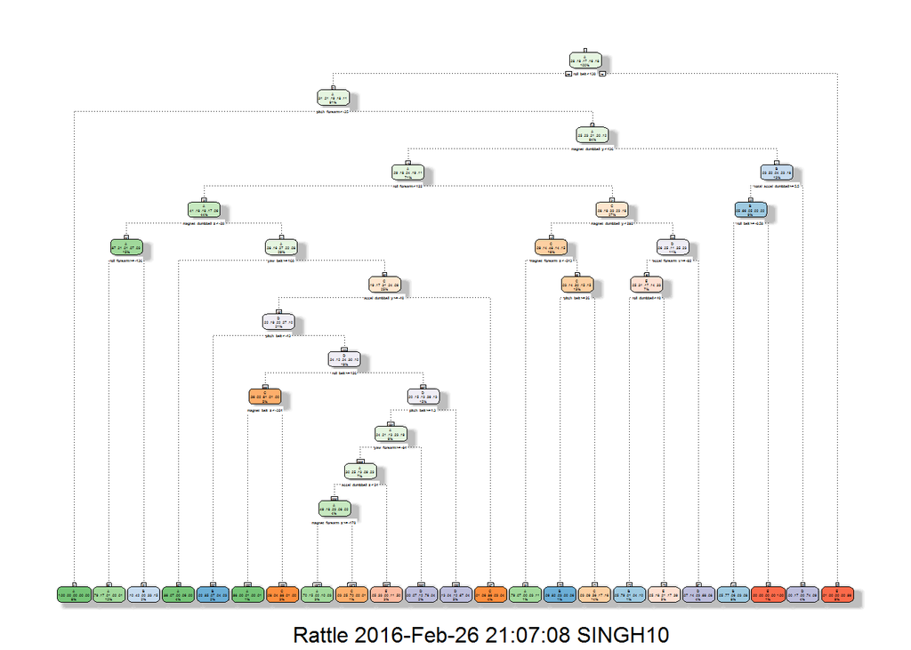

```r
modfitDS <- rpart(train60$classe ~ ., data=train60, method="class")
fancyRpartPlot(modfitDS)
```

## **2nd prediction model: Random Forest**

```r
modfitRF <- randomForest(train60$classe ~ ., data=train60, method="class")
```

### **Cross validation**

Cross validation will be performed on the subset of training data selected randomly. The data is split into (60% and 40%). The models will be fitted on the subset of training data set. Based on the most accurate outcome from Decision Tree and Random Forest models, the most accurate model will be tested with the main testing data set.

### **Decision Tree**

```r
predictionDS <- predict(modfitDS, train40, type="class")
confusionMatrix(predictionDS, train40$classe)
```

```
## Confusion Matrix and Statistics
##
##           Reference
## Prediction    A    B    C    D    E
##          A 1980  212   21   72   31
##          B   85  862   72   90   98
##          C   56  153 1086  209  175
##          D   71  101  110  823   89
##          E   40  190   79   92 1049
##
## Overall Statistics
##
##                Accuracy : 0.7392
##                  95% CI : (0.7294, 0.7489)
##     No Information Rate : 0.2845
##     P-Value [Acc > NIR] : < 2.2e-16
##
##                   Kappa : 0.6699
##  Mcnemar's Test P-Value : < 2.2e-16
##
## Statistics by Class:
##
##                      Class: A Class: B Class: C Class: D Class: E
## Sensitivity            0.8871   0.5679   0.7939   0.6400   0.7275
## Specificity            0.9401   0.9455   0.9085   0.9434   0.9374
## Pos Pred Value         0.8549   0.7142   0.6468   0.6893   0.7234
## Neg Pred Value         0.9544   0.9012   0.9543   0.9304   0.9386
## Prevalence             0.2845   0.1935   0.1744   0.1639   0.1838
## Detection Rate         0.2524   0.1099   0.1384   0.1049   0.1337
## Detection Prevalence   0.2952   0.1538   0.2140   0.1522   0.1848
## Balanced Accuracy      0.9136   0.7567   0.8512   0.7917   0.8324
```

### **Random Forest**

```r
predictionRF <- predict(modfitRF, train40, type="class")
confusionMatrix(predictionRF, train40$classe)
```

```
## Confusion Matrix and Statistics
##
##           Reference
## Prediction    A    B    C    D    E
##          A 2231   12    0    0    0
##          B    0 1501    9    0    0
##          C    0    5 1354   22    2
##          D    1    0    5 1262    2
##          E    0    0    0    2 1438
##
## Overall Statistics
##
##                Accuracy : 0.9924
##                  95% CI : (0.9902, 0.9942)
##     No Information Rate : 0.2845
##     P-Value [Acc > NIR] : < 2.2e-16
##
##                   Kappa : 0.9903
##  Mcnemar's Test P-Value : NA
##
## Statistics by Class:
##
##                      Class: A Class: B Class: C Class: D Class: E
## Sensitivity            0.9996   0.9888   0.9898   0.9813   0.9972
## Specificity            0.9979   0.9986   0.9955   0.9988   0.9997
## Pos Pred Value         0.9947   0.9940   0.9790   0.9937   0.9986
## Neg Pred Value         0.9998   0.9973   0.9978   0.9964   0.9994
## Prevalence             0.2845   0.1935   0.1744   0.1639   0.1838
## Detection Rate         0.2843   0.1913   0.1726   0.1608   0.1833
## Detection Prevalence   0.2859   0.1925   0.1763   0.1619   0.1835
## Balanced Accuracy      0.9987   0.9937   0.9926   0.9901   0.9985
```

### Expected out of sample error

Decision Tree Accuracy : 0.7392 at 95% CI : (0.7294, 0.7489) Random Forest Accuracy : 0.9924 at 95% CI : (0.9902, 0.9942) Compared to Decision Tree algorithm with Random Forest, Random Forest algorithm shows better accuracy. Based on the accuracy Random Forecast model is selected. The accuracy of the Random Forest model is 0.9924. The expected out of sample error is estimate at 0.008. The expected out of sample error is calculated as 1 minus accuracy for predictions against the cross validation set. With the chosen random forest model of accuracy above 99% on the cross validation data set, we can expect very few or none of the test samples should be misclassified.

## **Applying machine learning algorithm to the 20 test cases**

```r
predict20test <- predict(modfitRF, testset, type="class")
predict20test
```

```
##  1  2  3  4  5  6  7  8  9 10 11 12 13 14 15 16 17 18 19 20
##  B  A  B  A  A  E  D  B  A  A  B  C  B  A  E  E  A  B  B  B
## Levels: A B C D E
```

## References

[1] http://groupware.les.inf.puc-rio.br/har

*[2] Velloso, E.; Bulling, A.; Gellersen, H.; Ugulino, W.; Fuks, H. Qualitative Activity Recognition of Weight Lifting Exercises. Proceedings of 4th International Conference in Cooperation with SIGCHI (Augmented Human ’13) . Stuttgart, Germany: ACM SIGCHI, 2013.*